# Najkrótsza ścieżka między dwoma punktami na mapie (algorytm A*)

## Opis

Algorytm A* jest heurystycznym algorytmem służącym do znajdowania najkrótszej ścieżki w grafie. Jest to algorytm zupełny i optymalny, w tym sensie, że znajduje ścieżkę (droga bez powtarzalnych wierzchołków), jeśli tylko taka istnieje, i przy tym jest to ścieżka najkrótsza.

Algorytm A* działa najlepiej, gdy przestrzeń przeszukiwań jest przestrzenią drzewiastą. Stosowany głównie w dziedzinie sztucznej inteligencji do rozwiązywania problemów i w grach komputerowych do imitowania inteligentnego zachowania. Przykładowo Snake.

## Ogólne działanie algorytmu

Działanie algorytmu oparte jest na minimalizacji funkcji celu $f(x)$, zdefiniowanej jako suma funkcji kosztu $g(x)$ oraz funkcji heurystycznej $h(x)$. $$ f(x) = g(x) + h(x) $$

- $g(x)$ - droga miedzy węzłem początkowym a $x$. Dokładniej suma wag krawędzi, które należą już do ścieżki plus waga krawędzi łączącej aktualny węzeł z $x$.
- $h(x)$ - przewidywana przez heurystykę droga od x do węzła docelowego.

W każdym kroku algorytm A* przedłuża już utworzoną ścieżkę o kolejny wierzchołek grafu, wybierając taki, w którym wartość funkcji $f$ będzie najmniejsza.

Algorytm Dijkstry jest szczególnym przypadkiem algorytmu A*, w którym heurystyka wynosi 0 dla wszystkich węzłów.

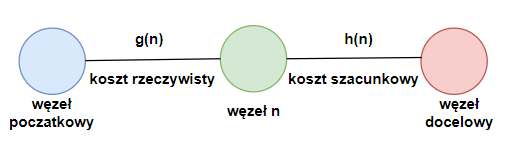

## Przykład graficzny

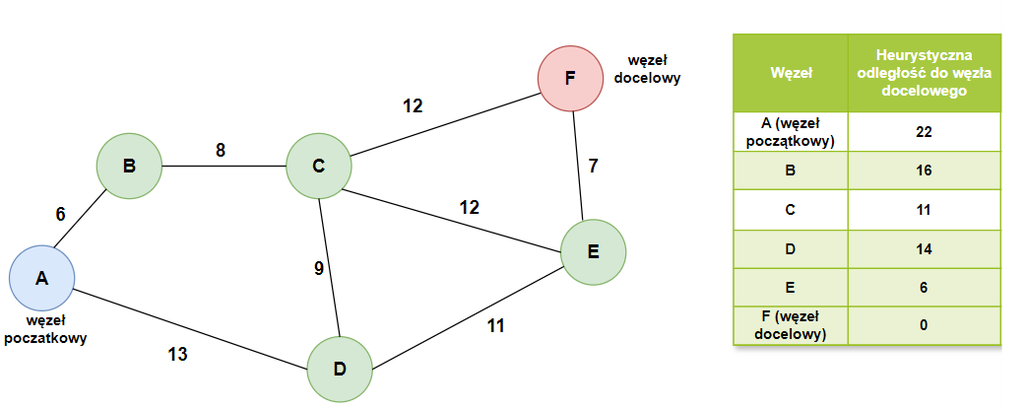

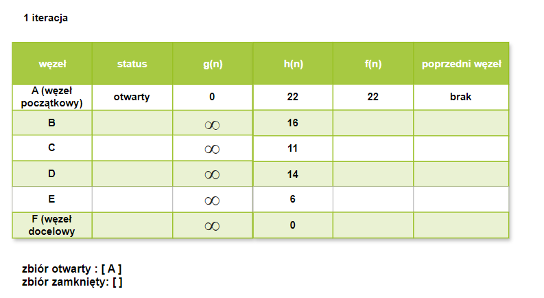

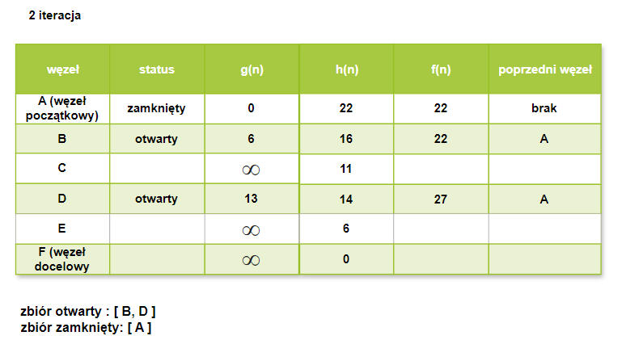

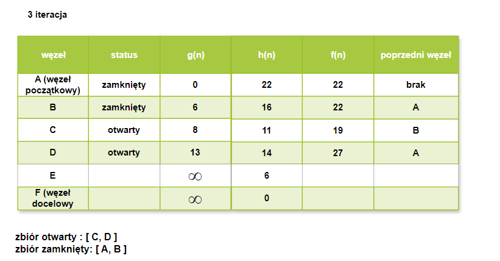

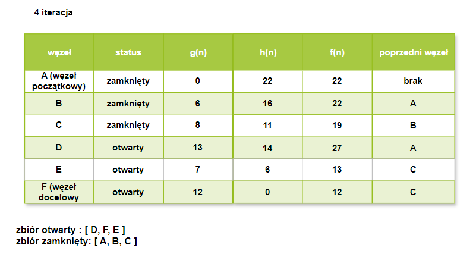

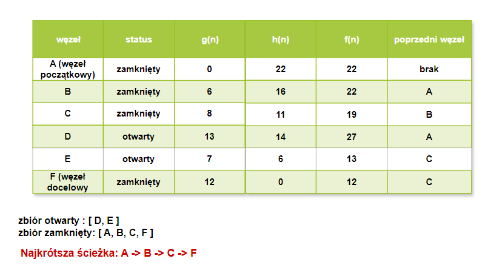

1. Inicjalizacja: Tworzymy zbiór otwarty, który na początku zawiera tylko węzeł startowy. Tworzymy również zbiór zamknięty, który na początku jest pusty. Węzeł startowy jest ustawiany jako swój własny węzeł nadrzędny, a jego odległość od siebie samego wynosi zero.
2. Przeszukiwanie: Dopóki zbiór otwarty nie jest pusty, wykonujemy następujące kroki:
- Wybieramy węzeł o najniższej wartości funkcji f (suma rzeczywistego kosztu dotarcia do węzła i heurystyki).
- Jeżeli wybrany węzeł jest węzłem docelowym, przechodzimy do kroku 4.
- W przeciwnym razie, dla każdego sąsiada wybranego węzła, obliczamy jego koszt dotarcia przez wybrany węzeł. Jeżeli ten koszt jest niższy niż dotychczasowy koszt dotarcia do sąsiada, aktualizujemy koszt dotarcia do sąsiada i ustawiamy wybrany węzeł jako jego węzeł nadrzędny. Jeżeli sąsiad nie był jeszcze odwiedzony, dodajemy go do zbioru otwartego.
- Usuwamy wybrany węzeł z zbioru otwartego i dodajemy go do zbioru zamkniętego.
1. Brak ścieżki: Jeżeli zbiór otwarty jest pusty i nie znaleźliśmy węzła docelowego, oznacza to, że nie istnieje ścieżka do węzła docelowego.
2. Rekonstrukcja ścieżki: Jeżeli znaleźliśmy węzeł docelowy, odtwarzamy ścieżkę od węzła docelowego do węzła startowego, idąc za wskaźnikami do węzłów nadrzędnych.

```python
class Graph:
    def __init__(self):
        self.nodes = {}
        self.heuristics = {}

    def add_node(self, name, neighbours):
        self.nodes[name] = neighbours

    def add_heuristic(self, name, heuristic):
        self.heuristics[name] = heuristic

    def get_neighbours(self, v):
        return self.nodes.get(v, None)

    def get_heuristic(self, n):
        return self.heuristics.get(n, None)


def aStarAlgo(graph, start_node, stop_node):
    open_set = set([start_node])
    closed_set = set()
    g = {}  # przechowuje odległość od węzła początkowego
    parents = {}  # Parents zawiera mapę sąsiedztwa wszystkich węzłów

    g[start_node] = 0
    parents[start_node] = start_node

    while len(open_set) > 0:
        n = None

        for v in open_set:
            if n == None or g[v] + graph.get_heuristic(v) < g[n] + graph.get_heuristic(n):
                n = v

        print(f'Aktualny węzeł: {n}')  # Wyświetlanie aktualnego węzła

        if n == stop_node or graph.get_neighbours(n) == None:
            pass
        else:
            for (m, weight) in graph.get_neighbours(n):
                if m not in open_set and m not in closed_set:
                    open_set.add(m)
                    parents[m] = n
                    g[m] = g[n] + weight
                else:
                    if g[m] > g[n] + weight:
                        g[m] = g[n] + weight
                        parents[m] = n

                        if m in closed_set:
                            closed_set.remove(m)
                            open_set.add(m)

        if n == None:
            print('Ścieżka nie istnieje!')
            return None

        if n == stop_node:
            path = []

            while parents[n] != n:
                path.append(n)
                n = parents[n]

            path.append(start_node)

            path.reverse()

            print('Znaleziona ścieżka: {}'.format(path))
            return path

        open_set.remove(n)
        closed_set.add(n)

    print('Ścieżka nie istnieje!')
    return None
```

### Przykład 1

```python
# Przykład
graph = Graph()
graph.add_node('A', [('B', 6), ('D', 13)])
graph.add_node('B', [('C', 8)])
graph.add_node('C', [('B', 8), ('D', 9), ('F', 12)])
graph.add_node('D', [('A', 13), ('C', 9)])
graph.add_node('E', [('C', 12), ('D', 11), ('F', 7)])
graph.add_node('F', [('C', 12), ('E', 7)])

graph.add_heuristic('A', 22)
graph.add_heuristic('B', 16)
graph.add_heuristic('C', 11)
graph.add_heuristic('D', 14)
graph.add_heuristic('E', 6)
graph.add_heuristic('F', 0)

aStarAlgo(graph, 'A', 'F')
```

```
Aktualny węzeł: A
Aktualny węzeł: B
Aktualny węzeł: C
Aktualny węzeł: F
Znaleziona ścieżka: ['A', 'B', 'C', 'F']
```

```
['A', 'B', 'C', 'F']
```

### Przykład 2

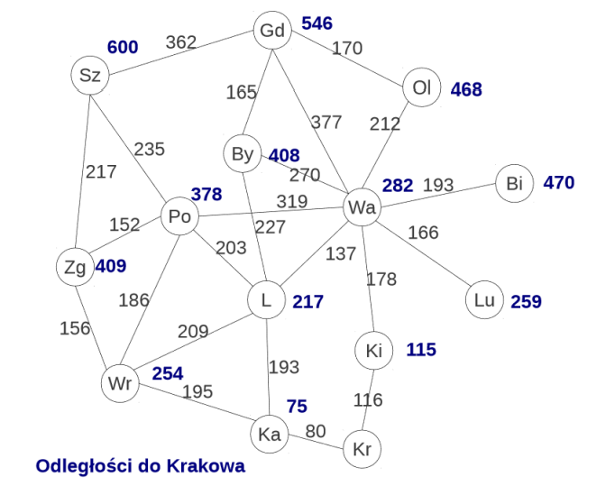

```python
graph = Graph()
graph.add_node('Kr', [('Ka', 80), ('Ki', 116)])
graph.add_node('Ka', [('Kr', 80), ('Wr', 195), ('L', 193)])
graph.add_node('Ki', [('Kr', 116), ('Wa', 178)])
graph.add_node('L', [('By', 227), ('Po', 203), ('Wa', 137), ('Ka', 193), ('Wr', 209)])
graph.add_node('Lu', [('Wa', 166)])
graph.add_node('Wa', [('L', 137), ('Bi', 193), ('Ol', 212), ('Lu', 166)])
graph.add_node('Po', [('L', 203), ('Sz', 235), ('Zg', 152), ('Wa', 319), ('Wr', 186)])
graph.add_node('Sz', [('Po', 235), ('Zg', 217), ('Gd', 362)])
graph.add_node('Zg', [('Po', 152), ('Wr', 156), ('Sz', 271)])
graph.add_node('Wr', [('Zg', 156), ('Ka', 195), ('L', 209), ('Po', 186)])
graph.add_node('Bi', [('Wa', 193)])
graph.add_node('Ol', [('Wa', 212), ('Gd', 170)])
graph.add_node('Gd', [('Sz', 362), ('Ol', 170), ('By', 165), ('Wa', 377)])
graph.add_node('By', [('L', 227), ('Wa', 270), ('Gd', 165)])
```

```python
graph.add_heuristic('Kr', 0)
graph.add_heuristic('Ka', 75)
graph.add_heuristic('Ki', 115)
graph.add_heuristic('L', 217)
graph.add_heuristic('Lu', 259)
graph.add_heuristic('Wa', 282)
graph.add_heuristic('Po', 378)
graph.add_heuristic('Sz', 600)
graph.add_heuristic('Zg', 409)
graph.add_heuristic('Wr', 254)
graph.add_heuristic('Bi', 470)
graph.add_heuristic('Ol', 468)
graph.add_heuristic('Gd', 546)
graph.add_heuristic('By', 408)

aStarAlgo(graph, 'Gd', 'Kr')
```

```
Aktualny węzeł: Gd
Aktualny węzeł: By
Aktualny węzeł: L
Aktualny węzeł: Ol
Aktualny węzeł: Wa
Aktualny węzeł: Ka
Aktualny węzeł: Kr
Znaleziona ścieżka: ['Gd', 'By', 'L', 'Ka', 'Kr']
```

```
['Gd', 'By', 'L', 'Ka', 'Kr']
```

## Labirynt

```python
import numpy as np

class Node():
    def __init__(self, parent=None, position=None):
        self.parent = parent
        self.position = position

        self.g = 0
        self.h = 0
        self.f = 0

    def __eq__(self, other):
        return self.position == other.position

def a_star_algorithm(labirynt, start, end):
    start_node = Node(None, start)
    start_node.g = start_node.h = start_node.f = 0
    end_node = Node(None, end)
    end_node.g = end_node.h = end_node.f = 0

    open_list = []
    closed_list = []

    open_list.append(start_node)

    while len(open_list) > 0:
        current_node = open_list[0]
        current_index = 0
        for index, item in enumerate(open_list):
            if item.f < current_node.f:
                current_node = item
                current_index = index

        open_list.pop(current_index)
        closed_list.append(current_node)

        if current_node == end_node:
            path = []
            current = current_node
            while current is not None:
                path.append(current.position)
                current = current.parent
            return path[::-1]

        children = []
        for new_position in [(0, -1), (0, 1), (-1, 0), (1, 0), (-1, -1), (-1, 1), (1, -1), (1, 1)]:
            node_position = (current_node.position[0] + new_position[0], current_node.position[1] + new_position[1])

            if node_position[0] > (len(labirynt) - 1) or node_position[0] < 0 or node_position[1] > (len(labirynt[len(labirynt)-1]) -1) or node_position[1] < 0:
                continue

            if labirynt[node_position[0]][node_position[1]] != 0:
                continue

            new_node = Node(current_node, node_position)

            children.append(new_node)

        for child in children:
            for closed_child in closed_list:
                if child == closed_child:
                    continue

            child.g = current_node.g + 1
            child.h = ((child.position[0] - end_node.position[0]) ** 2) + ((child.position[1] - end_node.position[1]) ** 2)
            child.f = child.g + child.h

            for open_node in open_list:
                if child == open_node and child.g > open_node.g:
                    continue

            open_list.append(child)

def main():
    labirynt = [[0, 0, 0, 0, 1, 0, 0, 0, 0, 0],
                [0, 0, 0, 0, 1, 0, 0, 0, 0, 0],
                [0, 0, 0, 0, 1, 0, 0, 0, 0, 0],
                [0, 0, 0, 0, 1, 0, 0, 0, 0, 0],
                [0, 0, 0, 0, 0, 0, 0, 0, 0, 0],
                [0, 0, 0, 0, 1, 0, 0, 0, 0, 0],
                [0, 0, 0, 0, 1, 0, 0, 0, 0, 0],
                [0, 0, 0, 0, 1, 0, 0, 0, 0, 0],
                [0, 0, 0, 0, 0, 0, 0, 0, 0, 0]]

    start = (0, 0)
    end = (7, 6)

    path = np.array(a_star_algorithm(labirynt, start, end))
    print(path)

if __name__ == '__main__':
    main()
```

```
[[0 0]
 [1 1]
 [2 2]
 [3 3]
 [4 4]
 [5 5]
 [6 6]
 [7 6]]
```